# Lab 3: Advanced Data Transformation

February 03, 2023

# Introduction

```r
flights
```

```
## # A tibble: 336,776 × 19
##     year month   day dep_time sched_de…¹ dep_d…² arr_t…³ sched…⁴ arr_d…⁵ carrier
##    <int> <int> <int>    <int>      <int>   <dbl>   <int>   <int>   <dbl> <chr>
##  1  2013     1     1      517        515       2     830     819      11 UA
##  2  2013     1     1      533        529       4     850     830      20 UA
##  3  2013     1     1      542        540       2     923     850      33 AA
##  4  2013     1     1      544        545      -1    1004    1022     -18 B6
##  5  2013     1     1      554        600      -6     812     837     -25 DL
##  6  2013     1     1      554        558      -4     740     728      12 UA
##  7  2013     1     1      555        600      -5     913     854      19 B6
##  8  2013     1     1      557        600      -3     709     723     -14 EV
##  9  2013     1     1      557        600      -3     838     846      -8 B6
## 10  2013     1     1      558        600      -2     753     745       8 AA
## # … with 336,766 more rows, 9 more variables: flight <int>, tailnum <chr>,
## #   origin <chr>, dest <chr>, air_time <dbl>, distance <dbl>, hour <dbl>,
## #   minute <dbl>, time_hour <dttm>, and abbreviated variable names
## #   ¹sched_dep_time, ²dep_delay, ³arr_time, ⁴sched_arr_time, ⁵arr_delay
## # ℹ Use `print(n = ...)` to see more rows, and `colnames()` to see all variable names
```

```r
print(getwd())
```

```
## [1] "/Users/susandavis/Downloads/GitHub/STOR-320/Lab-Assignments"
```

The main purpose of this tutorial is to put together all 5 key functions from **[dplyr](https://dplyr.tidyverse.org/reference/index.html)** and use them to create summary tables and delightful graphs in RMarkdown. The functions and their purposes are listed as follows:

- `filter()` *Selects Observations Based on Values*
- `arrange()` *Sorts Observations Based on Criteria*
- `select()` or `rename()` *Selects, Deselects, Renames, and Reorders Variables*
- `mutate()` or `transmute()` *Creates New Variables Which Were Originally Nonexistant*
- `summarize()` *Aggregates the Data Based on Helpful Summary Statistics*

To further incite your anger towards the airline industry, we will continue to practice our skills using the dataset `flights` by loading the R package `nycflights13`. Until we learn how to fly, this dataset remains relevant.

> I’ll spread my wings, and learn how to fly. I’ll do what it takes till I touch the sky.

> – Kelly Clarkson

# Part 1: Summarizing the Data (4 Points)

Using the pipe `%>%` to chain functions from `dplyr`, modify the code below to create a dataset named `flight.summary` that contains the following ordered modfications:

```r
flight.summary =

  #1
  flights %>%

  #2
  mutate(
    dep_min       = (dep_time%/%100)*60+dep_time%%100,
    sched_dep_min = (sched_dep_time%/%100)*60+sched_dep_time%%100,
    arr_min       = (arr_time%/%100)*60+arr_time%%100,
    sched_arr_min = (sched_arr_time%/%100)*60+sched_arr_time%%100,
    dep_delay_min = dep_min-sched_dep_min,
    arr_delay_min = arr_min-sched_arr_min,
    accuracy      = abs(dep_delay_min) + abs(arr_delay_min)
  ) %>%

  #3
  filter(complete.cases(.)) %>%

  #4
  group_by(origin,dest,carrier) %>%

  #5
  summarize(
    count=n(),
    mean.acc=mean(accuracy),
    var.acc= sd(accuracy),
    mean.dist= mean(distance)
  ) %>%

  #6
  filter(n() <= 10) %>%

  #7
  ungroup() %>%

  #8
  mutate(proportion= mean(n() >= 10))
head(flight.summary) #DO NOT CHANGE THIS LINE OF CODE
```

```
## # A tibble: 6 × 8
##   origin dest  carrier count mean.acc var.acc mean.dist proportion
##   <chr>  <chr> <chr>   <int>    <dbl>   <dbl>     <dbl>      <dbl>
## 1 EWR    ALB   EV        418     77.9  217.         143          1
## 2 EWR    ANC   UA          8     31.4   36.4       3370          1
## 3 EWR    ATL   9E          4     19.5    7.55       746          1
## 4 EWR    ATL   DL       3116     46.4  146.         746          1
## 5 EWR    ATL   EV       1654     91.3  257.         746          1
## 6 EWR    ATL   UA        102     46.5   94.3        746          1
```

# Part 2: Building Charts From Summary Data

### 2.1 (1 Point)

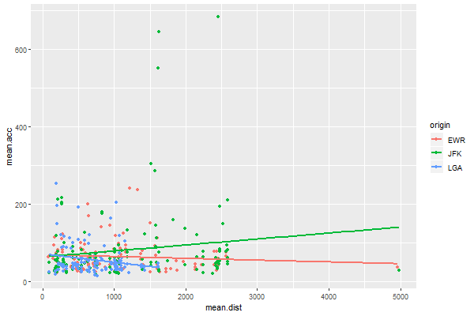

The purpose of creating this plot was to investigate if flight accuracy gets worse or better for longer flights. The chart above displays the approximated linear relationship between flight accuracy and flight distance for each the 3 NYC airports. This first image was created using a combination of `geom_point()` and `geom_smooth()`. Recreate this image using `ggplot()` and remember to modify the defaults of `geom_smooth()` to get linear trend lines without standard error regions.

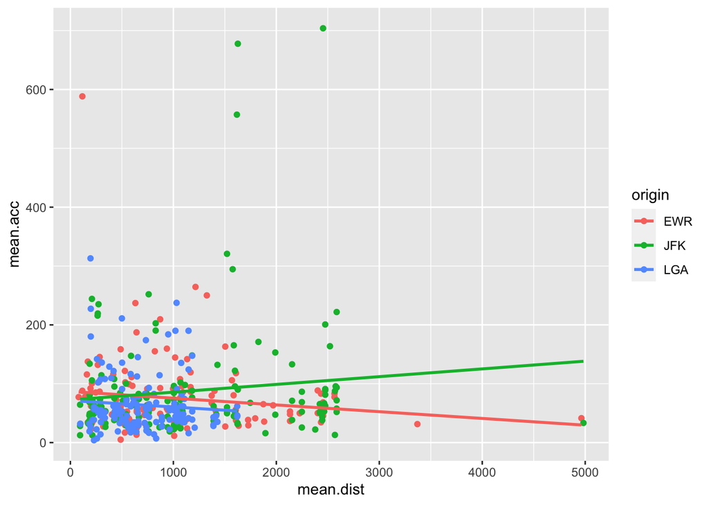

```r
ggplot(data=flight.summary) +
  geom_point(mapping = aes(x = mean.dist, y = mean.acc, color = origin))+
  geom_smooth(mapping = aes(x = mean.dist, y = mean.acc, color = origin),method = lm, se = FALSE)
```

### 2.2 (1 Point)

The first thing we notice is that not many flights are over 3000 miles in distance. Design a new plot similar to the one above that ignores the scenarios where the distance exceeds 3000. This will prevent rare occurrences from effecting our linear trend comparison and present these relationships in a zoomed-in window where the majority of data exists.

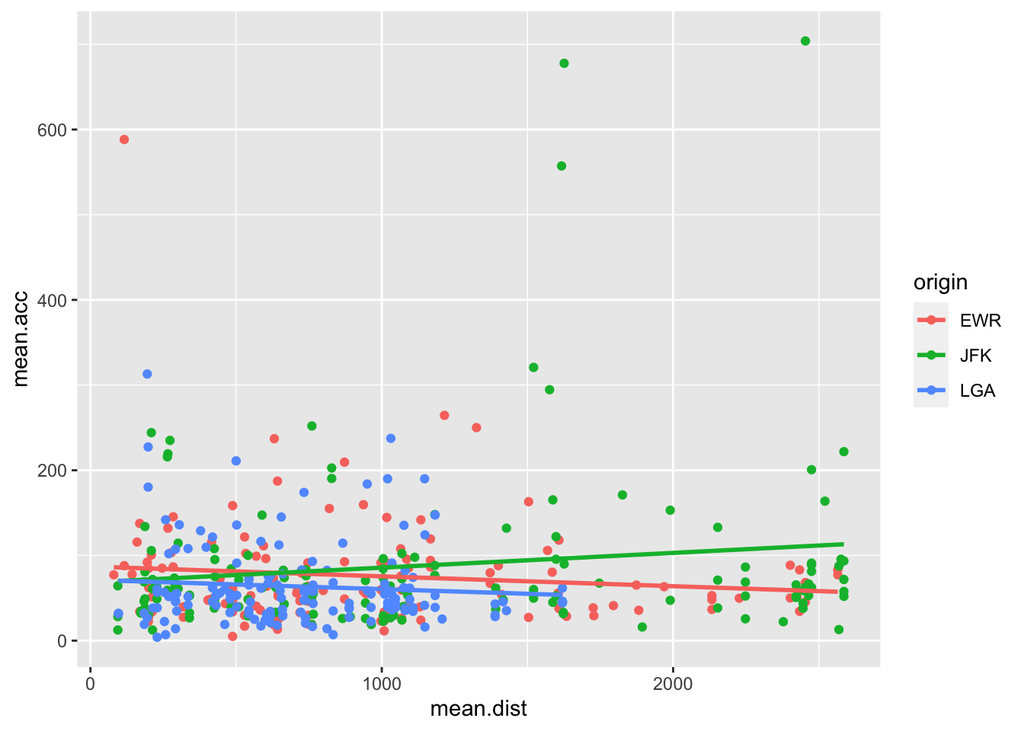

```r
ggplot(data=filter(flight.summary,mean.dist < 3000)) +
  geom_point(mapping = aes(x = mean.dist, y = mean.acc, color = origin)) +
  geom_smooth(mapping = aes(x = mean.dist, y = mean.acc, color = origin), method = lm, se = FALSE)
```

### 2.2 (1 Point)

Answer the following question using complete sentences:

Each trend line is doing different things. Which of the three originating airports is doing the worst regarding the relationship between flight accuracy and flight distance? Explain why.

# Part 3: Build a Nice Table to Be Displayed in RMarkdown (1 Point)

```r
flight.summary2 =
  flight.summary %>%
  mutate(rank=min_rank(mean.acc)) %>%
  filter(min_rank(mean.acc)<=5 | min_rank(desc(mean.acc))<=5) %>%
  arrange(rank)
```

The `kable()` function in the `knitr` package allows for creating HTML tables. For information about the `kable` package, click **[here](https://bookdown.org/yihui/rmarkdown-cookbook/kable.html)** Furthermore, the `kableExtra` package allows you to add beauty to those internet-ready tables. Click **[here](http://haozhu233.github.io/kableExtra/awesome_table_in_html.html)** for a helpful introduction.

Once you understand the function of `kable()` and the modifications you can apply, start an R code chunk to place the information required to produce an HTML table of `flight.summary2`.

```r
flight.summary2 %>%
  kbl() %>%
  kable_material(c("striped", "hover"))
```

| origin | dest | carrier | count | mean.acc | var.acc | mean.dist | proportion | rank |
| --- | --- | --- | --- | --- | --- | --- | --- | --- |
| LGA | IAD | OO | 1 | 4.0000 | NA | 229 | 1 | 1 |
| EWR | DTW | UA | 1 | 5.0000 | NA | 488 | 1 | 2 |
| LGA | BTV | 9E | 2 | 7.0000 | 7.071068 | 258 | 1 | 3 |
| LGA | JAX | DL | 1 | 7.0000 | NA | 833 | 1 | 3 |
| EWR | MSP | UA | 2 | 11.5000 | 9.192388 | 1008 | 1 | 5 |
| JFK | AUS | B6 | 742 | 320.7385 | 584.158205 | 1521 | 1 | 433 |
| JFK | PSE | B6 | 358 | 557.2235 | 690.320041 | 1617 | 1 | 434 |
| EWR | BDL | UA | 7 | 588.2857 | 1035.496936 | 116 | 1 | 435 |
| JFK | DEN | B6 | 336 | 677.7262 | 744.758638 | 1626 | 1 | 436 |
| JFK | PDX | B6 | 322 | 703.9689 | 727.245599 | 2454 | 1 | 437 |

# Part 4: Additional Questions (2 Points)

In this class you will be forced to analyze data you probably care very little about. *This is the part in the class where you begin to act like you care.* An important rule in this class is to “love thy data as thyself.” Consider the `flights` data from both the view of the airline executive and the customer. Given what you know about the data, write two questions that you would want to answer that would influence how you buy airline tickets.

1. What is the average on time arrival rate of Delta Airlines?

2)What is the average customer satisfaction rating for each airline? You would have to survey passangers after their flights. This could be done on the airlines mobile application. Each time a person finishes flying they could get a notification to fill out a satisfaction survey of their flight. Then when you add this column to the data you could group by carrier and compare satisfaction ratings across the differing airline companies.